# 이미지 분류 문제를 위한 Deep Convolutional Neural Network (CNN)의 Python Keras, Theano, Tensorflow library를 이용한 구현 및 실습

#### 2017. 8. 21.

#### 최영원 (youngwon08@gmail.com)

#### 서울대학교 통계학과

## Contents

1. Introduction
2. Keras 라이브러리
3. 딥 러닝을 위한 데이터 전처리와 결과 처리를 위한 python 기초
4. 딥 러닝을 위한 Theano 기초
5. 딥 러닝을 위한 Tensorflow 기초
6. MNIST 데이터를 위한 deep convolutional network
7. CIFAR10 데이터를 위한 deep convolutional network
8. Transfer Learning

## Introductoin

### 딥 러닝이란?

- 딥 러닝은 여러겹의 은닉층으로 이루어진 인공 신경망(Artificial neural networks, ANN) 을 말함.
- Artificial Neuron and Perceptron

[figure not shown]

(http://homepages.gold.ac.uk/nikolaev/311perc.htm)

- 인공 신경망 (ANN)

[figure not shown]

(https://www.extremetech.com/extreme/215170-artificial-neural-networks-are-changing-the-world-what-are-they)

## Introductoin

### 딥 러닝이란?

- 계층적 구성
  - 사람의 뇌가 단순한 뉴런의 네트워크로 이루어져 있듯이, 복잡한 모델링을 기반으로 만들어졌던 인공 신경망(ANN)을 여러 겹의 단순한 계산 단위로 표현
  - 복잡한 예측 모형을 나타내기 위해서는 층을 적게 쌓으면 계산 단위가 매우 많이 필요함
  - 딥 러닝에서는 한 층의 계산 단위 수를 제한하기 위해 여러 겹의 층을 쌓음

## Introductoin

### 딥 러닝이란?

[figure not shown]

(https://stats.stackexchange.com/questions/182734/what-is-the-difference-between-a-neural-network-and-a-deep-neural-network, http://neuralnetworksanddeeplearning.com/chap5.html)

## Introduction

### 딥 러닝이란?

- 딥 러닝 기초
  1. Model : Multilayer Perceptron (MLP), Convolutional Neural Network (CNN), Recurrent Neural Network (RNN), etc.
  2. Regularization : Dropout, Early-Stopping, etc.
  3. Loss function
     - Classification : Negative Log-Likelihood Loss ($\mathcal{D} $ is the training set) $$ NLL(\theta, \mathcal{D}) = - \sum_{i=0}^{|\mathcal{D}|} \log P(Y=y^{(i)} | x^{(i)}, \theta)) $$
     - Regression : Mean Squared Error
  4. Training
     - Optimization method : Stochastic Gradient Descent (SGD)
     - Back-propagation algorithm : calculates the gradient of the loss function.
     - Batch & Epoch

## Introductoin

### 딥 러닝의 훈련(Training)이 어려운 이유

- Vanishing gradient
  - 딥 러닝은 기본적으로 back-propagation 알고리즘을 이용해 훈련
  - 제일 끝단에서 첫단으로 정보를 전달하는 과정에서 정보를 점점 잃어버리게 됨
- Overfitting
  - 뉴럴 네트워크(neural net)는 데이터에 비해 파라미터가 더 많은 모형
  - 훈련 데이터의 노이즈까지 모두 적합시켜 일반화가 잘 안됨
  - 딥 뉴럴 네트워크(deep neural net)는 이런 현상이 더 심각함
- 해결책
  1. convolutional layers 등의 차원 축소 방법
  2. 더욱 강력한 안정화 방법 (dropout, convolutional layers 등)
  3. sigmoid 뉴런을 대체할 rectified linear units 등의 뉴런 모델
  4. GPU 등의 병렬화 기법

## Introductoin

### Deep Convolutional Neural Networks (DCNN)

[figure not shown]

(https://en.wikipedia.org/wiki/Convolutional_neural_network)

[figure not shown]

(http://cs231n.github.io/convolutional-networks/)

- 이미지 인식에 적합한 뉴럴 네트워크의 구조
- "Gradient-based learning applied to document recognition", Yann LeCun, Léon Bottou, Yoshua Bengio, and Patrick Haffner (1998)

### Convolutional layer

- 커널(kernel)과 입력 이미지의 컨볼루션(convolution)을 통해 feature를 얻는 과정
- 컨볼루션 필터(convolution filter)들을 각각 전체 이미지에 적용
- 네트워크 연결의 가중치 공유 $\rightarrow$ 파라미터 수를 줄임
- 이미지의 모든 부분에 동일한 필터 적용
- j, k번째 은닉 뉴런 $$a^1_{j,k}=\sigma\left(b+\sum_{l=0}^4\sum_{m=0}^4 \omega_{l,m} * a^0_{j+l,k+l}\right)$$
  - $*$ : 컨볼루션 연산자
- feature는 위치에 관계없이 검출됨 (이미지의 이동불변성(translation invariance)을 활용)

(http://cs231n.github.io/convolutional-networks/#conv)

### Pooling layer (sub-sampling layer)

| Pooling layer downsamples the volume spatially | Max Pooling |
| --- | --- |

(http://cs231n.github.io/convolutional-networks/#conv)

- Convolution layer으로부터 나온 출력을 단순화 (차원 축소)
- Max-pooling : 입력 영역의 최대값
- L2 pooling : 입력 영역의 제곱합의 제곱근

### Fully-connected layer

- Convolutional layer에서 얻어진 국소적 정보를 종합해 좀 더 추상적인 내용을 학습
- Dropout 안정화 방법
  - 네트워크에서 은닉 계산 단위를 무작위로 (그리고 임시적으로) 삭제
  - 모형이 노이즈에 강건하도록 보장하는 하나의 방법

### Final layer

- softmax 함수
  - 입력이 class L에 속할 확률 ($L = 1, 2, ...$) $$a_j^L=\frac{e^{z_j^L}}{\sum_ke^{z_k^L}}$$

## Introduction

### Resources and pointers to information about Deep Learning

- Books : [Deep Learning](http://www.iro.umontreal.ca/~bengioy/dlbook/), Yoshua Bengio, Ian Goodfellow, Aaron Courville, MIT Press, In preparation.
- Deep Learning Net Reading List : http://deeplearning.net/reading-list/
- Deep Learning Net Tutorial List : http://deeplearning.net/reading-list/tutorials/
- Online Courses
  - Geoffrey Hinton’s [Online Neural networks Course](https://class.coursera.org/neuralnets-2012-001/class) on Coursera.
  - [CS231n](http://cs231n.stanford.edu/): Convolutional Neural Networks for Visual Recognition
  - [CS224d](http://cs224d.stanford.edu/): Deep Learning for Natural Language Processing

## Introduction

### Deep Learning Software

#### Deep-learning Software

- [Theano](http://deeplearning.net/software/theano/index.html)
- [Caffe](http://caffe.berkeleyvision.org)
- [TensorFlow](https://www.tensorflow.org)
- [Torch](http://torch.ch/)

#### High level API

- [Keras](http://keras.io)
- [TF Learn(tf.contrib.learn)](http://tflearn.org/)

#### 특징

- Caffe는 보다 큰 마켓에 딥러닝을 적용하려는 목적을 가지고 있는 반면 Torch나 Theano는 딥러닝 그 자체 연구에 더 적합
- Licensing
  - Theano/Torch/Caffe: BSD License
  - TensorFlow: Apache 2.0 open source license

## Introduction

### 실습을 위한 프로그램 및 패키지 설치

- [Anaconda](https://www.continuum.io/downloads) : A completely free Python distribution (including for commercial use and redistribution)
- theano 설치 (참고 : http://deeplearning.net/software/theano/install.html)

```
conda install theano pygpu
```

- tensorflow 설치 (참고: https://www.tensorflow.org/install/)

```
conda install tensorflow
```

- keras 설치 (참고 : https://keras.io/#installation)

```
conda install keras
```

## Keras 라이브러리

- high-level neural networks API
- Backend : TensorFlow, CNTK, Theano backend를 제공
  - ~/.keras/keras.json 에서 backend 선택 가능
  - 환경변수 설정으로 backend 선택 가능 (e.g. `export KERAS_BACKEND=tensorflow`)
- For Windows

```python
%%cmd
cd C:/Users/isdn2/.keras/
type keras.json
```

```
Microsoft Windows [Version 10.0.15063]
(c) 2017 Microsoft Corporation. All rights reserved.

(C:\Users\isdn2\Anaconda3) C:\Users\isdn2\Desktop\deep_learning_jupyter>cd C:/Users/isdn2/.keras/

(C:\Users\isdn2\Anaconda3) C:\Users\isdn2\.keras>type keras.json
{
    "floatx": "float32",
    "epsilon": 1e-07,
    "backend": "tensorflow",
    "image_data_format": "channels_last"
}
(C:\Users\isdn2\Anaconda3) C:\Users\isdn2\.keras>
```

- For Linux & Mac OS

```python
%%bash
cat ~/.keras/keras.json
```

```python
import keras
print(keras.__version__)
print(keras.backend.backend())
```

```
2.0.6
tensorflow
```

## 딥 러닝 데이터와 결과 처리를 위한 python 기초

### 실습 목표

1. Keras 라이브러리의 다양한 데이터 베이스 활용
2. 딥 러닝을 위한 Numpy 데이터 처리
3. 데이터 확인을 위한 matplotlib 기초

### [Keras Datasets](http://keras.io/datasets/) 활용

- Image data : [CIFAR10 image classification](http://keras.io/datasets/#cifar10-small-image-classification), [MNIST database of handwritten digits](http://keras.io/datasets/#mnist-database-of-handwritten-digits)
- Word data : [IMDB Movie reviews sentiment classification](http://keras.io/datasets/#imdb-movie-reviews-sentiment-classification), [Reuters newswire topics classification](http://keras.io/datasets/#reuters-newswire-topics-classification)
- `(X_train, y_train), (X_test, y_test) = datasets.load_data(param)`

### 딥 러닝을 위한 Numpy 데이터 처리

- Numpy 기초

```python
from keras.utils import np_utils
import numpy as np

a = np.array([0,0,1,1,2,2,1,1,3,3,0,0])
b = np.array([(0,1,2),(1,3,0)])

print('a')
print('type=',type(a), ', shape=', a.shape, ', ndim=', a.ndim)
print('data type=', a.dtype.name)
print('item size=', a.itemsize, ', size=', a.size)

print('b')
print('type=',type(b), ', shape=', b.shape, ', ndim=', b.ndim)
print('data type=', b.dtype.name)
print('item size=', b.itemsize, ', size=', b.size)
```

```
a
type= <class 'numpy.ndarray'> , shape= (12,) , ndim= 1
data type= int32
item size= 4 , size= 12
b
type= <class 'numpy.ndarray'> , shape= (2, 3) , ndim= 2
data type= int32
item size= 4 , size= 6
```

```python
a = a.reshape(6,2)
b = b.reshape(6)

a = a.astype('float32')
c = np_utils.to_categorical(b, 4)

print('a')
print('type=',type(a), ', shape=', a.shape, ', ndim=', a.ndim)
print('data type=', a.dtype.name)
print('item size=', a.itemsize, ', size=', a.size)

print('c')
print('type=',type(c), ', shape=', c.shape, ', ndim=', c.ndim)
print('data type=', c.dtype.name)
print('item size=', c.itemsize, ', size=', c.size)
```

```
a
type= <class 'numpy.ndarray'> , shape= (6, 2) , ndim= 2
data type= float32
item size= 4 , size= 12
c
type= <class 'numpy.ndarray'> , shape= (6, 4) , ndim= 2
data type= float64
item size= 8 , size= 24
```

```python
from keras.models import Sequential
from keras.layers.core import Dense, Activation
from keras.optimizers import SGD

model = Sequential()
model.add(Dense(4, kernel_initializer='uniform', input_shape=(2,), activation='softmax'))
model.compile(loss='mse', optimizer='sgd', metrics=['accuracy'])

model.fit(a, c, batch_size=1, epochs=3, verbose=1)
```

```
<keras.callbacks.History at 0x264411b9358>
```

### 딥 러닝을 위한 Numpy 데이터 처리

- PNG 이미지로 딥 러닝을 위한 Numpy 데이터 만들기

```
img shape (512, 512)
```

[figure not shown]

```
type= <class 'numpy.ndarray'> , shape= (1, 1, 512, 512) , ndim= 4
data type= float32
item size= 4 , size= 262144
```

```python
import matplotlib.pyplot as plt
import matplotlib.image as mpimg
import numpy as np

img = mpimg.imread('http://people.sc.fsu.edu/~jburkardt/data/png/lena.png')
print('img shape', img.shape)
plt.imshow(img, cmap='bone')
plt.show()

img = img.reshape(1,1,512,512)
print('type=',type(img), ', shape=', img.shape, ', ndim=', img.ndim)
print('data type=', img.dtype.name)
print('item size=', img.itemsize, ', size=', img.size)
```

### 딥 러닝을 위한 Numpy 데이터 처리

- PNG color 이미지로 딥 러닝을 위한 Numpy 데이터 만들기

```
img shape (512, 512, 3)
```

[figure not shown]

```
type= <class 'numpy.ndarray'> , shape= (1, 3, 512, 512) , ndim= 4
data type= float32
item size= 4 , size= 786432
```

```python
import matplotlib.pyplot as plt
import matplotlib.image as mpimg
import numpy as np

img = mpimg.imread('https://upload.wikimedia.org/wikipedia/en/2/24/Lenna.png')
print('img shape', img.shape)
plt.imshow(img)
plt.show()

img = img.transpose(2, 0, 1)
img = img.reshape(1, 3, 512, 512)
print('type=',type(img), ', shape=', img.shape, ', ndim=', img.ndim)
print('data type=', img.dtype.name)
print('item size=', img.itemsize, ', size=', img.size)
```

## 딥 러닝을 위한 Theano 기초

### Theano

- Yoshua Bengio 교수가 이끄는 몬트리올 대학 LISA 연구실에서 개발한 Python 라이브러리
- Symbolic computatoinal graphs 기반
- 언어 : Python (내부는 속도를 위해 C로 구현), GPU 지원
  - Numpy-like syntax 사용
- 인터프리터와 컴파일러를 합침
  - 빠른 prototyping
  - 빠른 실행 속도 (C/CUDA 코드 생성기)
- Symbolic computation
  - 미분 자동화 (프로그래밍 감소)
- 역할 분담
  - 사람: 생성 공식을 주고, 조각들을 합침
  - Theano는 특정 추론/계산을 최적화
    - CPU/GPU 계산을 같은 코드로 할 수 있음
- 기존의 개발 환경 활용 가능
  - Python, NumPy, SciPy, MatPlotLib

#### Compilation

- **표준화(canonicalization)**: symbolic 표현을 간단하게 함
- **수치 안정화(stabilization)**: 수치적 안정성을 향상시킴
  - 예. $\log(1+\exp(x))$
- **특수화(specialization)**: 더 빠른 계산 방법을 선택
  - 예. $pow(x,2) \rightarrow sqr(x)$, 행렬 곱셈 $\rightarrow$ BLAS GEMM, 전치/부분 텐서 $\rightarrow$ 상수 시간 메모리 에일리어싱
  - 만약 GPU가 사용되면, GPU에 적합한 것으로 선택
- **GPU 변환**: GPU 메모리로 `float32`형 데이터를 보냄
- **코드 생성**: 파이썬 모듈 동적 컴파일

#### Theano의 4 단계 사용 방법

1. 입력 타입을 선언
2. Symbolic 계산 : 수식 분석
3. 컴파일 : C/CUDA 코드를 만들고 컴파일
4. 계산 : 실제로 함수를 계산하고 모델을 훈련
- 입력 타입 선언 및 Sympolic 계산

[figure not shown]

(http://deeplearning.net/software/theano/extending/graphstructures.html)

```python
import theano.tensor as T
from theano import function, pp, printing

x = T.dscalar('x')
y = T.dscalar('y')
z = x + y
```

- pretty-print out the computation associated to z

```python
print(pp(z))
```

```
(x + y)
```

- compile the subgraph z, and produce a callable f

```python
f = function([x, y], z)
f(2, 3)
```

```
array(5.0)
```

- Matrix 계산 예제

```python
x = T.dmatrix('x')
y = T.dmatrix('y')
z = x + y

f = function([x, y], z)
f(np.array([[1, 2],[3, 4]]), np.array([[5, 6],[7, 8]]))
```

```
array([[  6.,   8.],
       [ 10.,  12.]])
```

## 딥 러닝을 위한 Tensorflow 기초

### Tensorflow

- Google Brain Team 에서 개발
- Data Flow Graph 기반
- 언어 : Python (내부는 속도를 위해 C/C++로 구현)
- Portability: 다중 CPU, 다중 GPU 계산 및 모바일 환경을 위한 API 제공
- Flexibility: Raspberry Pi, Android, Windows, iOS, Linux
- 뛰어난 시각화 기능 (TensorBoard)
- 미분 자동화

#### Data Flow Graph

[figure not shown]

(https://www.tensorflow.org/)

- Nodes와 edges로 구성된 directed graph 를 통한 계산
- **Nodes** : mathematical operations
  - 데이터 입력단을, 결과 출력단을 나타내기도 함
  - 계산 디바이스에 할당됨
- **edges** : 노드 사이의 관계

#### [TensorBoard: Visualizing Learning](https://www.tensorflow.org/versions/r0.8/how_tos/summaries_and_tensorboard/index.html)

[figure not shown]

(https://www.tensorflow.org/)

#### [TensorBoard: Graph Visualization](https://www.tensorflow.org/versions/r0.8/how_tos/graph_viz/index.html)

[figure not shown]

(https://www.tensorflow.org/)

### Tensorflow 기반의 High level API **TF Learn(tf.contrib.learn)** 기초

```python
import tensorflow as tf
import numpy as np

# Create 100 phony x, y data points in NumPy, y = x * 0.1 + 0.3
x_data = np.random.rand(100).astype(np.float32)
y_data = x_data * 0.1 + 0.3

# Try to find values for W and b that compute y_data = W * x_data + b
# (We know that W should be 0.1 and b 0.3, but Tensorflow will
# figure that out for us.)
W = tf.Variable(tf.random_uniform([1], -1.0, 1.0))
b = tf.Variable(tf.zeros([1]))
y = W * x_data + b

# Minimize the mean squared errors.
loss = tf.reduce_mean(tf.square(y - y_data))
optimizer = tf.train.GradientDescentOptimizer(0.5)
train = optimizer.minimize(loss)

# Before starting, initialize the variables.  We will 'run' this first.
init = tf.global_variables_initializer()

# Launch the graph.
sess = tf.Session()
sess.run(init)

# Fit the line.
for step in range(201):
    sess.run(train)
    if step % 20 == 0:
        print('step \t{} \t- W : {}, b : {}'.format(step, sess.run(W), sess.run(b)))
```

```
step 	0 	- W : [ 0.27155212], b : [ 0.2816374]
step 	20 	- W : [ 0.1361836], b : [ 0.28116196]
step 	40 	- W : [ 0.10918836], b : [ 0.29521632]
step 	60 	- W : [ 0.10233327], b : [ 0.29878527]
step 	80 	- W : [ 0.1005925], b : [ 0.29969153]
step 	100 	- W : [ 0.10015047], b : [ 0.29992169]
step 	120 	- W : [ 0.10003821], b : [ 0.29998013]
step 	140 	- W : [ 0.10000971], b : [ 0.29999498]
step 	160 	- W : [ 0.10000248], b : [ 0.29999873]
step 	180 	- W : [ 0.10000065], b : [ 0.29999968]
step 	200 	- W : [ 0.10000017], b : [ 0.29999992]
```

- Learns best fit is W: [0.1], b: [0.3]

## MNIST 데이터를 위한 deep convolutional network

### 실습 목표

1. MNIST 데이터를 이용해 네트워크를 훈련하고, model, weight, history 저장하기
2. MNIST 데이터를 이용해 훈련한 네트워크를 불러오기

### MNIST datasets (Modified National Institute of Standards and Technology database)

[figure not shown]

(http://neuralnetworksanddeeplearning.com/chap1.html)

- [MNIST datasets](http://keras.io/datasets/#mnist-database-of-handwritten-digits) : `[Sample_size, Rows, Cols]`
  - Rows = 28, Cols=28
  - Sample_size : 60000개의 training set, 10000개의 test set

### 이미지 분류 문제를 위한 CNN 네트워크를 구성하고 MNIST 데이터를 이용해 훈련 및 저장하기

- 훈련을 위한 데이터 준비하기

```python
import numpy as np
import json

from keras.datasets import mnist
from keras.models import Sequential
from keras.layers.core import Dense, Dropout, Activation, Flatten
from keras.layers.convolutional import Conv2D, MaxPooling2D
from keras.utils import np_utils
from keras import backend as K
import matplotlib.pyplot as plt
%matplotlib inline

np.random.seed(1337)  # for reproducibility

# the data, shuffled and split between tran and test sets
(X_train, y_train), (X_test, y_test) = mnist.load_data()

if K.image_dim_ordering() == 'th':
    X_train = X_train.reshape(X_train.shape[0], 1, 28, 28)
    X_test = X_test.reshape(X_test.shape[0], 1, 28, 28)
    input_shape = (1, 28, 28)
else:
    X_train = X_train.reshape(X_train.shape[0], 28, 28, 1)
    X_test = X_test.reshape(X_test.shape[0], 28, 28, 1)
    input_shape = (28, 28, 1)

X_train = X_train.astype('float32')
X_test = X_test.astype('float32')
X_train /= 255
X_test /= 255

# convert class vectors to binary class matrices
Y_train = np_utils.to_categorical(y_train, num_classes=10)
Y_test = np_utils.to_categorical(y_test, num_classes=10)

print('\nX_train shape:', X_train.shape)
print('Y_train shape:', Y_train.shape)
print(X_train.shape[0], 'train samples')
print(X_test.shape[0], 'test samples')
```

```
X_train shape: (60000, 28, 28, 1)
Y_train shape: (60000, 10)
60000 train samples
10000 test samples
```

- 이미지 분류 문제를 위한 CNN 네트워크를 구성하기

```python
model = Sequential()
model.add(Conv2D(filters=16, kernel_size=(5,5), padding='valid', input_shape=input_shape))
model.add(Activation('relu'))
model.add(Conv2D(filters=16, kernel_size=(5,5), padding='valid'))
model.add(Activation('relu'))
model.add(MaxPooling2D(pool_size=(2, 2)))
model.add(Dropout(0.5))
model.add(Flatten())
model.add(Dense(128))
model.add(Activation('relu'))
model.add(Dropout(0.5))
model.add(Dense(10))
model.add(Activation('softmax'))
```

```python
model.summary()
```

```
_________________________________________________________________
Layer (type)                 Output Shape              Param #
=================================================================
conv2d_1 (Conv2D)            (None, 24, 24, 16)        416
_________________________________________________________________
activation_1 (Activation)    (None, 24, 24, 16)        0
_________________________________________________________________
conv2d_2 (Conv2D)            (None, 20, 20, 16)        6416
_________________________________________________________________
activation_2 (Activation)    (None, 20, 20, 16)        0
_________________________________________________________________
max_pooling2d_1 (MaxPooling2 (None, 10, 10, 16)        0
_________________________________________________________________
dropout_1 (Dropout)          (None, 10, 10, 16)        0
_________________________________________________________________
flatten_1 (Flatten)          (None, 1600)              0
_________________________________________________________________
dense_2 (Dense)              (None, 128)               204928
_________________________________________________________________
activation_3 (Activation)    (None, 128)               0
_________________________________________________________________
dropout_2 (Dropout)          (None, 128)               0
_________________________________________________________________
dense_3 (Dense)              (None, 10)                1290
_________________________________________________________________
activation_4 (Activation)    (None, 10)                0
=================================================================
Total params: 213,050
Trainable params: 213,050
Non-trainable params: 0
_________________________________________________________________
```

- 네트워크 컴파일 하기

```python
model.compile(loss='categorical_crossentropy',
              optimizer='sgd',
              metrics=['accuracy'])
```

- 네트워크 훈련하기

```python
hist = model.fit(X_train, Y_train, batch_size=32, epochs=10, verbose=1, validation_split=0.2)
```

```
Train on 48000 samples, validate on 12000 samples
```

- 테스트 데이터로 훈련된 네트워크의 성능 확인

```python
score = model.evaluate(X_test, Y_test, verbose=1)
print('Test score:', score[0])
print('Test accuracy:', score[1])
```

```
Test accuracy: 0.9862
```

- 훈련된 네트워크의 model, weight, history 저장하기

```python
# Save the model
json_string = model.to_json()
with open('mnist_model_architecture.json','w') as f:
    f.write(json_string)

# Save the weights
model.save_weights('mnist_model_weights.h5')

# Save History
with open('mnist_model_history.json','w') as fp:
    json.dump(hist.history, fp)
```

- History 확인 하기

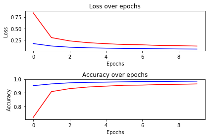

```python
# Plot history
hist = json.loads(open('mnist_model_history.json').read())

plt.figure('history')
plt.subplot(211)
plt.title('Loss over epochs')
plt.plot(hist['loss'],'r',label='loss')
plt.plot(hist['val_loss'], 'b',label='val_loss')
plt.xlabel('Epochs')
plt.ylabel('Loss')

plt.subplot(212)
plt.title('Accuracy over epochs')
plt.plot(hist['acc'],'r',label='acc')
plt.plot(hist['val_acc'], 'b',label='val_acc')
plt.xlabel('Epochs')
plt.ylabel('Accuracy')

plt.tight_layout()
plt.show()
```

### MNIST 데이터를 이용해 훈련한 네트워크 불러오기

- 훈련된 네트워크의 성능 확인을 위한 테스트 데이터 준비하기

```python
from keras.datasets import mnist
from keras.models import Sequential

from keras.models import model_from_json
from keras import backend as K
import json
import matplotlib.pyplot as plt
%matplotlib inline

# the data, shuffled and split between tran and test sets
(X_train, y_train), (X_test, y_test) = mnist.load_data()

if K.image_dim_ordering() == 'th':
    X_test = X_test.reshape(X_test.shape[0], 1, 28, 28)
    input_shape = (1, 28, 28)
else:
    X_test = X_test.reshape(X_test.shape[0], 28, 28, 1)
    input_shape = (28, 28, 1)

X_test = X_test.astype('float32')
X_test /= 255
print(X_test.shape[0], 'test samples')
```

```
10000 test samples
```

- 훈련한 네트워크 불러오기

```python
# Reconstruct model
model = model_from_json(open('mnist_model_architecture.json').read())
model.load_weights('mnist_model_weights.h5')
model.summary()
```

```
_________________________________________________________________
Layer (type)                 Output Shape              Param #
=================================================================
conv2d_1 (Conv2D)            (None, 24, 24, 16)        416
_________________________________________________________________
activation_1 (Activation)    (None, 24, 24, 16)        0
_________________________________________________________________
conv2d_2 (Conv2D)            (None, 20, 20, 16)        6416
_________________________________________________________________
activation_2 (Activation)    (None, 20, 20, 16)        0
_________________________________________________________________
max_pooling2d_1 (MaxPooling2 (None, 10, 10, 16)        0
_________________________________________________________________
dropout_1 (Dropout)          (None, 10, 10, 16)        0
_________________________________________________________________
flatten_1 (Flatten)          (None, 1600)              0
_________________________________________________________________
dense_2 (Dense)              (None, 128)               204928
_________________________________________________________________
activation_3 (Activation)    (None, 128)               0
_________________________________________________________________
dropout_2 (Dropout)          (None, 128)               0
_________________________________________________________________
dense_3 (Dense)              (None, 10)                1290
_________________________________________________________________
activation_4 (Activation)    (None, 10)                0
=================================================================
Total params: 213,050
Trainable params: 213,050
Non-trainable params: 0
_________________________________________________________________
```

- Test 결과 확인하기

```python
print('Predict classes')
classes = model.predict_classes(X_test, batch_size=32)

print('\nPredicted class : ', classes)
```

```
Predict classes

Predicted class :  [7 2 1 ..., 4 5 6]
```

```python
print('Predict probability')
proba = model.predict_proba(X_test, batch_size=32)

print('\nPredicted probabitlity : ', proba)
```

```
Predict probability
Predicted probabitlity :  [[  7.07792580e-09   4.52323290e-09   3.48219987e-06 ...,   9.99990463e-01
    4.72587258e-09   4.78067705e-07]
 [  2.49572327e-06   2.06786135e-04   9.99788582e-01 ...,   2.96467850e-09
    1.39666531e-06   1.41830631e-10]
 [  8.89039526e-08   9.99865532e-01   6.20417086e-06 ...,   2.26062602e-05
    1.75988225e-05   2.73026876e-06]
 ...,
 [  1.80158189e-12   2.05785202e-08   6.75972819e-11 ...,   9.34661415e-08
    1.40406073e-07   6.88627597e-06]
 [  4.77066521e-07   7.36784429e-08   2.35456312e-08 ...,   2.74791088e-08
    3.14209587e-03   5.64940819e-06]
 [  9.23749326e-07   6.09266237e-09   1.19540437e-06 ...,   1.38194118e-11
    2.90406970e-08   1.79840609e-09]]
```

- 각 층의 Activation 확인 하기

```python
# Get output of each layer
get_1st_layer_output = K.function([model.layers[0].input,
                                   K.learning_phase()],
                                  [model.layers[0].output])
get_2nd_layer_output = K.function([model.layers[0].input,
                                   K.learning_phase()],
                                  [model.layers[2].output])
get_3rd_layer_output = K.function([model.layers[0].input,
                                   K.learning_phase()],
                                  [model.layers[7].output])
get_last_layer_output = K.function([model.layers[0].input,
                                   K.learning_phase()],
                                  [model.layers[10].output])
print('X_test image shape:', X_test.shape)
layer_1_output = get_1st_layer_output([X_test,0])[0]
print('Print 1st layer output', layer_1_output.shape)
layer_2_output = get_2nd_layer_output([X_test,0])[0]
print('Print 2nd layer output', layer_2_output.shape)
layer_3_output = get_3rd_layer_output([X_test,0])[0]
print('Print 3rd layer output', layer_3_output.shape)
layer_last_output = get_last_layer_output([X_test,0])[0]
print('Print last layer output', layer_last_output.shape)
```

```
X_test image shape: (10000, 28, 28, 1)
Print 1st layer output (10000, 24, 24, 16)
Print 2nd layer output (10000, 20, 20, 16)
Print 3rd layer output (10000, 128)
Print last layer output (10000, 10)
```

```python
def plotvalue(index):
    plt.figure('Input data and 1~4 layer output value of X_test[{idx}]'.format(idx=index),
               figsize=(9,6))
    plt.subplot2grid((5,6),(0,0),rowspan=2,colspan=2)
    plt.title('Input data')
    plt.imshow(X_test[index][:,:,0], cmap='bone', interpolation='nearest')
    plt.subplot2grid((5,6),(0,2))
    plt.imshow(layer_1_output[index][:,:,0], cmap='bone', interpolation='nearest')
    plt.subplot2grid((5,6),(0,3))
    plt.imshow(layer_1_output[index][:,:,1], cmap='bone', interpolation='nearest')
    plt.subplot2grid((5,6),(1,2))
    plt.imshow(layer_1_output[index][:,:,2], cmap='bone', interpolation='nearest')

    plt.subplot2grid((5,6),(0,4))
    plt.imshow(layer_2_output[index][:,:,0], cmap='bone', interpolation='nearest')
    plt.subplot2grid((5,6),(0,5))
    plt.imshow(layer_2_output[index][:,:,1], cmap='bone', interpolation='nearest')
    plt.subplot2grid((5,6),(1,4))
    plt.imshow(layer_2_output[index][:,:,2], cmap='bone', interpolation='nearest')

    plt.subplot2grid((5,6),(2,0),colspan=6)
    plt.imshow(layer_3_output[index].reshape(1,layer_3_output.shape[1]), cmap='bone', interpolation='nearest')

    plt.subplot2grid((5,6),(3,0),colspan=6)
    plt.title('probability prediction')
    plt.plot(proba[index],'r',label='probability')

    plt.subplot2grid((5,6),(4,0),colspan=6)
    plt.title('Last layer output={ans}, y_test={sol}'.format(ans=classes[index],sol=y_test[index]))
    plt.imshow(layer_last_output[index].reshape(1,layer_last_output.shape[1]),
               cmap='bone', interpolation='nearest')

    plt.tight_layout()
    plt.show()
```

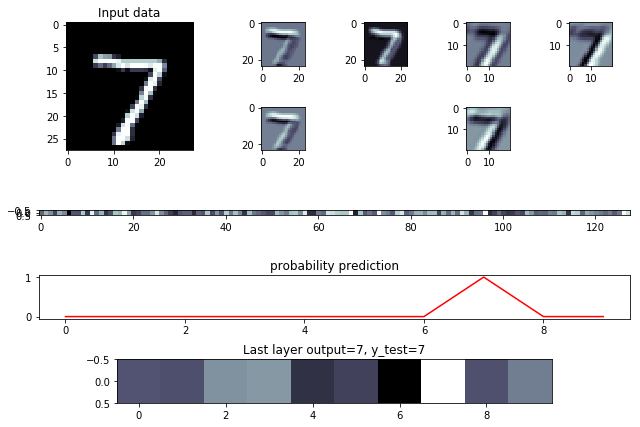

```python
plotvalue(0)
```

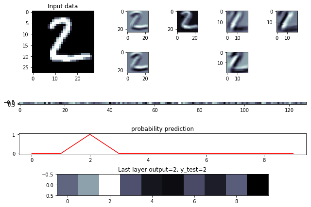

```python
plotvalue(1)
```

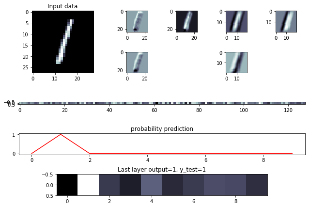

```python
plotvalue(2)
```

## CIFAR10 데이터를 위한 deep convolutional network

### CIFAR-10 dataset

[figure not shown]

(https://www.kaggle.com/c/cifar-10)

- [CIFAR-10 dataset](http://keras.io/datasets/#cifar10-small-image-classification) : `[Sample_size, Channels, Rows, Cols]`
  - Channels = RGB (각 `0~255`), Rows = 32, Cols=32
  - Sample_size : 50000개의 training set, 10000개의 test set

### 이미지 분류 문제를 위한 CNN 네트워크를 구성하고 CIFAR10 데이터를 이용해 훈련 및 저장하기

```python
import numpy as np
import json

from keras.datasets import cifar10
from keras.preprocessing.image import ImageDataGenerator
from keras.models import Sequential
from keras.layers.core import Dense, Dropout, Activation, Flatten
from keras.layers.convolutional import Conv2D, MaxPooling2D
from keras.utils import np_utils, generic_utils
from keras import backend as K

np.random.seed(1337)  # for reproducibility

# the data, shuffled and split between train and test sets
(X_train, y_train), (X_test, y_test) = cifar10.load_data()

if K.image_dim_ordering() == 'th':
    X_train = X_train.reshape(X_train.shape[0], 3, 32, 32)
    X_test = X_test.reshape(X_test.shape[0], 3, 32, 32)
    input_shape = (3, 32, 32)
else:
    X_train = X_train.reshape(X_train.shape[0], 32, 32, 3)
    X_test = X_test.reshape(X_test.shape[0], 32, 32, 3)
    input_shape = (32, 32, 3)

X_train = X_train.astype('float32')
X_test = X_test.astype('float32')
X_train /= 255
X_test /= 255
print('X_train shape:', X_train.shape)
print(X_train.shape[0], 'train samples')
print(X_test.shape[0], 'test samples')

# convert class vectors to binary class matrices
Y_train = np_utils.to_categorical(y_train, 10)
Y_test = np_utils.to_categorical(y_test, 10)
```

```
X_train shape: (50000, 32, 32, 3)
50000 train samples
10000 test samples
```

```python
model = Sequential()
model.add(Conv2D(filters=16, kernel_size=(5,5), padding='valid', input_shape=input_shape))
model.add(Activation('relu'))
model.add(Conv2D(filters=16, kernel_size=(5,5), padding='valid'))
model.add(Activation('relu'))
model.add(MaxPooling2D(pool_size=(2, 2)))
model.add(Dropout(0.5))
model.add(Flatten())
model.add(Dense(128))
model.add(Activation('relu'))
model.add(Dropout(0.5))
model.add(Dense(10))
model.add(Activation('softmax'))
```

```python
model.summary()
```

```
_________________________________________________________________
Layer (type)                 Output Shape              Param #
=================================================================
conv2d_3 (Conv2D)            (None, 28, 28, 16)        1216
_________________________________________________________________
activation_5 (Activation)    (None, 28, 28, 16)        0
_________________________________________________________________
conv2d_4 (Conv2D)            (None, 24, 24, 16)        6416
_________________________________________________________________
activation_6 (Activation)    (None, 24, 24, 16)        0
_________________________________________________________________
max_pooling2d_2 (MaxPooling2 (None, 12, 12, 16)        0
_________________________________________________________________
dropout_3 (Dropout)          (None, 12, 12, 16)        0
_________________________________________________________________
flatten_2 (Flatten)          (None, 2304)              0
_________________________________________________________________
dense_4 (Dense)              (None, 128)               295040
_________________________________________________________________
activation_7 (Activation)    (None, 128)               0
_________________________________________________________________
dropout_4 (Dropout)          (None, 128)               0
_________________________________________________________________
dense_5 (Dense)              (None, 10)                1290
_________________________________________________________________
activation_8 (Activation)    (None, 10)                0
=================================================================
Total params: 303,962
Trainable params: 303,962
Non-trainable params: 0
_________________________________________________________________
```

```python
model.compile(loss='categorical_crossentropy', optimizer='adam', metrics=['accuracy'])
```

```python
hist = model.fit(X_train, Y_train, batch_size=32, epochs=2, verbose=1, validation_split=0.2)
```

```
Train on 40000 samples, validate on 10000 samples
```

```python
score = model.evaluate(X_test, Y_test, verbose=1)
print('\nTest score:', score[0])
print('Test accuracy:', score[1])
```

```
Test score: 1.31913356304
Test accuracy: 0.5303
```

```python
# Save the model
json_string = model.to_json()
with open('cifar10_model_architecture.json','w') as f:
    f.write(json_string)

# Save the weights
model.save_weights('cifar10_model_weights.h5')

# Save History
with open('cifar10_model_history.json','w') as fp:
    json.dump(hist.history, fp)
```

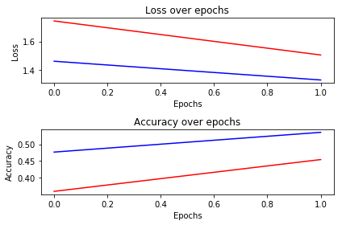

```python
# Plot history
hist = json.loads(open('cifar10_model_history.json').read())

plt.figure('history')
plt.subplot(211)
plt.title('Loss over epochs')
plt.plot(hist['loss'],'r',label='loss')
plt.plot(hist['val_loss'], 'b',label='val_loss')
plt.xlabel('Epochs')
plt.ylabel('Loss')

plt.subplot(212)
plt.title('Accuracy over epochs')
plt.plot(hist['acc'],'r',label='acc')
plt.plot(hist['val_acc'], 'b',label='val_acc')
plt.xlabel('Epochs')
plt.ylabel('Accuracy')

plt.tight_layout()
plt.show()
```

### CIFAR 10 데이터를 이용해 훈련한 네트워크 불러오기

```python
# the data, shuffled and split between tran and test sets
(X_train, y_train), (X_test, y_test) = cifar10.load_data()
if K.image_dim_ordering() == 'th':
    X_test = X_test.reshape(X_test.shape[0], 3, 32, 32)
    input_shape = (3, 32, 32)
else:
    X_test = X_test.reshape(X_test.shape[0], 32, 32, 3)
    input_shape = (32, 32, 3)
X_test = X_test.astype('float32')
X_test /= 255
print(X_test.shape[0], 'test samples')
```

```
10000 test samples
```

```python
# Reconstruct model
model = model_from_json(open('cifar10_model_architecture.json').read())
model.load_weights('cifar10_model_weights.h5')
model.summary()
```

```
_________________________________________________________________
Layer (type)                 Output Shape              Param #
=================================================================
conv2d_3 (Conv2D)            (None, 28, 28, 16)        1216
_________________________________________________________________
activation_5 (Activation)    (None, 28, 28, 16)        0
_________________________________________________________________
conv2d_4 (Conv2D)            (None, 24, 24, 16)        6416
_________________________________________________________________
activation_6 (Activation)    (None, 24, 24, 16)        0
_________________________________________________________________
max_pooling2d_2 (MaxPooling2 (None, 12, 12, 16)        0
_________________________________________________________________
dropout_3 (Dropout)          (None, 12, 12, 16)        0
_________________________________________________________________
flatten_2 (Flatten)          (None, 2304)              0
_________________________________________________________________
dense_4 (Dense)              (None, 128)               295040
_________________________________________________________________
activation_7 (Activation)    (None, 128)               0
_________________________________________________________________
dropout_4 (Dropout)          (None, 128)               0
_________________________________________________________________
dense_5 (Dense)              (None, 10)                1290
_________________________________________________________________
activation_8 (Activation)    (None, 10)                0
=================================================================
Total params: 303,962
Trainable params: 303,962
Non-trainable params: 0
_________________________________________________________________
```

```python
print('Predict classes')
classes = model.predict_classes(X_test, batch_size=32)

print('\nPredicted class : ', classes)
```

```
Predict classes
Predicted class :  [3 8 8 ..., 5 4 7]
```

```python
print('Predict probability')
proba = model.predict_proba(X_test, batch_size=32)

print('\nPredicted probabitlity : ', proba)
```

```
Predict probability
Predicted probabitlity :  [[  2.63162088e-02   1.22306449e-02   1.57329619e-01 ...,   2.58538108e-02
    3.67962979e-02   1.63311474e-02]
 [  1.02600306e-01   2.28016049e-01   2.68631760e-04 ...,   6.48459491e-06
    6.21658266e-01   4.73622791e-02]
 [  1.83707952e-01   1.08365275e-01   7.32772751e-03 ...,   1.83246483e-03
    5.89648545e-01   1.03819408e-01]
 ...,
 [  1.75736763e-03   2.93076911e-04   1.07697904e-01 ...,   5.14816158e-02
    5.28725795e-04   1.32815598e-03]
 [  8.16586539e-02   1.57529652e-01   1.38215467e-01 ...,   6.89365566e-02
    3.30130681e-02   8.94154981e-02]
 [  8.11202824e-03   8.23642768e-04   4.21694033e-02 ...,   7.79696703e-01
    4.95472283e-04   4.81664995e-03]]
```

```python
# Get output of each layer
get_1st_layer_output = K.function([model.layers[0].input, K.learning_phase()], [model.layers[0].output])
get_2nd_layer_output = K.function([model.layers[0].input, K.learning_phase()], [model.layers[2].output])
get_3rd_layer_output = K.function([model.layers[0].input, K.learning_phase()], [model.layers[7].output])
get_last_layer_output = K.function([model.layers[0].input, K.learning_phase()], [model.layers[10].output])
print('X_test image shape:', X_test.shape)
layer_1_output = get_1st_layer_output([X_test,0])[0]
print('Print 1st layer output', layer_1_output.shape)
layer_2_output = get_2nd_layer_output([X_test,0])[0]
print('Print 2nd layer output', layer_2_output.shape)
layer_3_output = get_3rd_layer_output([X_test,0])[0]
print('Print 3rd layer output', layer_3_output.shape)
layer_last_output = get_last_layer_output([X_test,0])[0]
print('Print last layer output', layer_last_output.shape)
```

```
X_test image shape: (10000, 32, 32, 3)
Print 1st layer output (10000, 28, 28, 16)
Print 2nd layer output (10000, 24, 24, 16)
Print 3rd layer output (10000, 128)
Print last layer output (10000, 10)
```

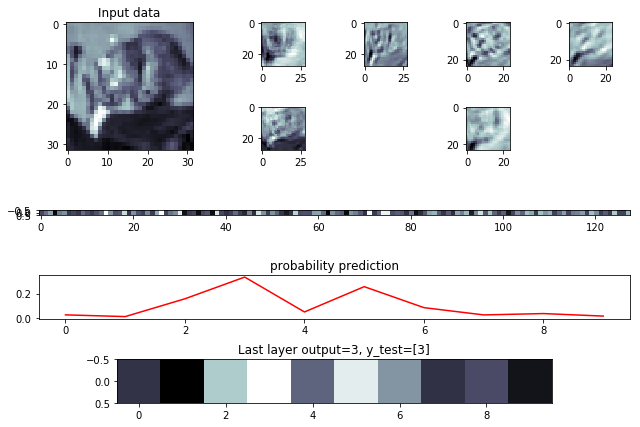

```python
plotvalue(0)
```

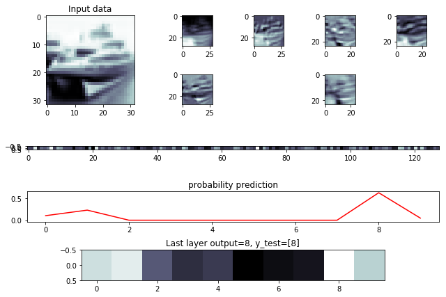

```python
plotvalue(1)
```

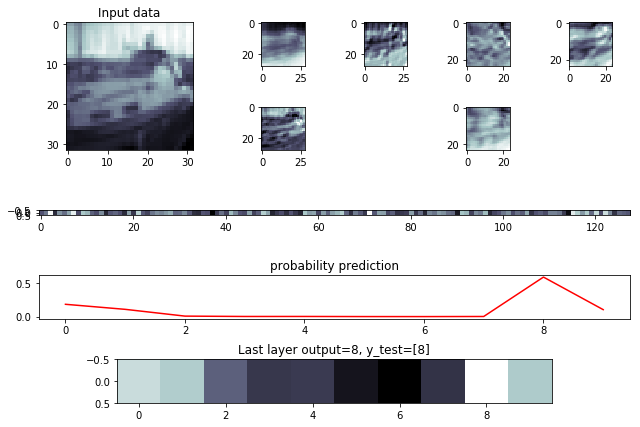

```python
plotvalue(2)
```

## Transfer Learning

- 미리 훈련된 네트워크를 불러와서 Fine-tuning 하기
- Keras가 제공하는 이미지 분류를 위한 미리 훈련된 네트워크 (참고: https://keras.io/applications/)
  - Xception
  - VGG16
  - VGG19
  - ResNet50
  - InceptionV3
  - MobileNet

### Imagenet dataset으로 미리 훈련된 VGG16 네트워크를 이용한 Fine-tune

(https://keras.io/applications/)

```python
from keras.applications.vgg16 import VGG16
from keras.preprocessing import image
from keras.models import Model
from keras.layers import Dense, GlobalAveragePooling2D
from keras import backend as K

# create the base pre-trained model
base_model = VGG16(weights='imagenet', include_top=False)

base_model.summary()
```

```
_________________________________________________________________
Layer (type)                 Output Shape              Param #
=================================================================
input_1 (InputLayer)         (None, None, None, 3)     0
_________________________________________________________________
block1_conv1 (Conv2D)        (None, None, None, 64)    1792
_________________________________________________________________
block1_conv2 (Conv2D)        (None, None, None, 64)    36928
_________________________________________________________________
block1_pool (MaxPooling2D)   (None, None, None, 64)    0
_________________________________________________________________
block2_conv1 (Conv2D)        (None, None, None, 128)   73856
_________________________________________________________________
block2_conv2 (Conv2D)        (None, None, None, 128)   147584
_________________________________________________________________
block2_pool (MaxPooling2D)   (None, None, None, 128)   0
_________________________________________________________________
block3_conv1 (Conv2D)        (None, None, None, 256)   295168
_________________________________________________________________
block3_conv2 (Conv2D)        (None, None, None, 256)   590080
_________________________________________________________________
block3_conv3 (Conv2D)        (None, None, None, 256)   590080
_________________________________________________________________
block3_pool (MaxPooling2D)   (None, None, None, 256)   0
_________________________________________________________________
block4_conv1 (Conv2D)        (None, None, None, 512)   1180160
_________________________________________________________________
block4_conv2 (Conv2D)        (None, None, None, 512)   2359808
_________________________________________________________________
block4_conv3 (Conv2D)        (None, None, None, 512)   2359808
_________________________________________________________________
block4_pool (MaxPooling2D)   (None, None, None, 512)   0
_________________________________________________________________
block5_conv1 (Conv2D)        (None, None, None, 512)   2359808
_________________________________________________________________
block5_conv2 (Conv2D)        (None, None, None, 512)   2359808
_________________________________________________________________
block5_conv3 (Conv2D)        (None, None, None, 512)   2359808
_________________________________________________________________
block5_pool (MaxPooling2D)   (None, None, None, 512)   0
=================================================================
Total params: 14,714,688
Trainable params: 14,714,688
Non-trainable params: 0
_________________________________________________________________
```

- 새로운 데이터의 분류를 위해 마지막 단 추가하기

```python
# add a global spatial average pooling layer
x = base_model.output
x = GlobalAveragePooling2D()(x)
# and add a logistic layer -- let's say we have 10 classes
predictions = Dense(10, activation='softmax')(x)

# this is the model we will train
model = Model(inputs=base_model.input, outputs=predictions)

model.summary()
```

```
_________________________________________________________________
Layer (type)                 Output Shape              Param #
=================================================================
input_1 (InputLayer)         (None, None, None, 3)     0
_________________________________________________________________
block1_conv1 (Conv2D)        (None, None, None, 64)    1792
_________________________________________________________________
block1_conv2 (Conv2D)        (None, None, None, 64)    36928
_________________________________________________________________
block1_pool (MaxPooling2D)   (None, None, None, 64)    0
_________________________________________________________________
block2_conv1 (Conv2D)        (None, None, None, 128)   73856
_________________________________________________________________
block2_conv2 (Conv2D)        (None, None, None, 128)   147584
_________________________________________________________________
block2_pool (MaxPooling2D)   (None, None, None, 128)   0
_________________________________________________________________
block3_conv1 (Conv2D)        (None, None, None, 256)   295168
_________________________________________________________________
block3_conv2 (Conv2D)        (None, None, None, 256)   590080
_________________________________________________________________
block3_conv3 (Conv2D)        (None, None, None, 256)   590080
_________________________________________________________________
block3_pool (MaxPooling2D)   (None, None, None, 256)   0
_________________________________________________________________
block4_conv1 (Conv2D)        (None, None, None, 512)   1180160
_________________________________________________________________
block4_conv2 (Conv2D)        (None, None, None, 512)   2359808
_________________________________________________________________
block4_conv3 (Conv2D)        (None, None, None, 512)   2359808
_________________________________________________________________
block4_pool (MaxPooling2D)   (None, None, None, 512)   0
_________________________________________________________________
block5_conv1 (Conv2D)        (None, None, None, 512)   2359808
_________________________________________________________________
block5_conv2 (Conv2D)        (None, None, None, 512)   2359808
_________________________________________________________________
block5_conv3 (Conv2D)        (None, None, None, 512)   2359808
_________________________________________________________________
block5_pool (MaxPooling2D)   (None, None, None, 512)   0
_________________________________________________________________
global_average_pooling2d_1 ( (None, 512)               0
_________________________________________________________________
dense_6 (Dense)              (None, 10)                5130
=================================================================
Total params: 14,719,818
Trainable params: 14,719,818
Non-trainable params: 0
_________________________________________________________________
```

```python
# first: train only the top layers (which were randomly initialized)
# i.e. freeze all convolutional InceptionV3 layers
for layer in base_model.layers:
    layer.trainable = False
```

```python
model.compile(optimizer='adam', loss='categorical_crossentropy', metrics=['accuracy'])
```

```python
model.summary()
```

```
_________________________________________________________________
Layer (type)                 Output Shape              Param #
=================================================================
input_1 (InputLayer)         (None, None, None, 3)     0
_________________________________________________________________
block1_conv1 (Conv2D)        (None, None, None, 64)    1792
_________________________________________________________________
block1_conv2 (Conv2D)        (None, None, None, 64)    36928
_________________________________________________________________
block1_pool (MaxPooling2D)   (None, None, None, 64)    0
_________________________________________________________________
block2_conv1 (Conv2D)        (None, None, None, 128)   73856
_________________________________________________________________
block2_conv2 (Conv2D)        (None, None, None, 128)   147584
_________________________________________________________________
block2_pool (MaxPooling2D)   (None, None, None, 128)   0
_________________________________________________________________
block3_conv1 (Conv2D)        (None, None, None, 256)   295168
_________________________________________________________________
block3_conv2 (Conv2D)        (None, None, None, 256)   590080
_________________________________________________________________
block3_conv3 (Conv2D)        (None, None, None, 256)   590080
_________________________________________________________________
block3_pool (MaxPooling2D)   (None, None, None, 256)   0
_________________________________________________________________
block4_conv1 (Conv2D)        (None, None, None, 512)   1180160
_________________________________________________________________
block4_conv2 (Conv2D)        (None, None, None, 512)   2359808
_________________________________________________________________
block4_conv3 (Conv2D)        (None, None, None, 512)   2359808
_________________________________________________________________
block4_pool (MaxPooling2D)   (None, None, None, 512)   0
_________________________________________________________________
block5_conv1 (Conv2D)        (None, None, None, 512)   2359808
_________________________________________________________________
block5_conv2 (Conv2D)        (None, None, None, 512)   2359808
_________________________________________________________________
block5_conv3 (Conv2D)        (None, None, None, 512)   2359808
_________________________________________________________________
block5_pool (MaxPooling2D)   (None, None, None, 512)   0
_________________________________________________________________
global_average_pooling2d_1 ( (None, 512)               0
_________________________________________________________________
dense_6 (Dense)              (None, 10)                5130
=================================================================
Total params: 14,719,818
Trainable params: 5,130
Non-trainable params: 14,714,688
_________________________________________________________________
```

```python
hist = model.fit(X_train, Y_train, batch_size=32, epochs=2, verbose=1, validation_split=0.2)
```

```
Train on 40000 samples, validate on 10000 samples
```

```python
score = model.evaluate(X_test, Y_test, verbose=1)
print('\nTest score:', score[0])
print('Test accuracy:', score[1])
```

[output not shown]

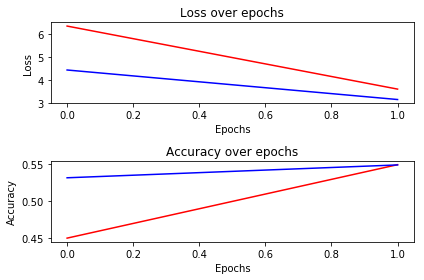

```python
plt.figure('history')
plt.subplot(211)
plt.title('Loss over epochs')
plt.plot(hist.history['loss'],'r',label='loss')
plt.plot(hist.history['val_loss'], 'b',label='val_loss')
plt.xlabel('Epochs')
plt.ylabel('Loss')

plt.subplot(212)
plt.title('Accuracy over epochs')
plt.plot(hist.history['acc'],'r',label='acc')
plt.plot(hist.history['val_acc'], 'b',label='val_acc')
plt.xlabel('Epochs')
plt.ylabel('Accuracy')

plt.tight_layout()
plt.show()
```

## GPU 사용

- nvidia CUDA driver, CUDA Toolkit의 설치

#### Theano Backend

- libgpuarray 패키지 설치 (참조 : http://deeplearning.net/software/libgpuarray/installation.html)

```
conda install pygpu
```

- GPU 사용이 가능한 컴퓨터의 경우, Theano에서 제공하는 GPU 병렬화 기능을 사용하기 위해서는 환경변수를 GPU 계산을 위해 셋팅해야 함. (참고: http://deeplearning.net/software/theano/library/config.html)
  - 다음과 같이 Theano flag 셋팅 Theano flag를 GPU 계산을 위해 셋팅 후 코드를 실행

    ```
    THEANO_FLAGS=mode=FAST_RUN,device=cuda,floatX=float32
    ```

#### Tensorflow Backend

- tensorflow-gpu 패키지 설치 (참조 : https://www.tensorflow.org/install/)